# NFL Salary Modeling by Position Group

Jacob Cohen and Michael Nichols

2025-12-12

# 1. Load Packages and Data

```r
library(tidyverse)
library(knitr)    # tables
library(broom)    # tidy model output
library(ggplot2)  # plots

# File paths (assumes the .Rmd lives in the same folder as the CSVs)
Offense <- read.csv("merged_players_offense_yearly_combined.csv")
Defense <- read.csv("merged_players_defense_yearly_combined.csv")
```

# 2. Data Filtering and Position Groups

In this section we restrict the data to the most recent 12 seasons and create broad position groups that roughly align with how front offices value players: quarterbacks (QB), running backs (RB), pass-catchers (WR/TE), and defense.

```r
# Determine last season year in each dataset
last_year_off <- max(Offense$season__yr_off, na.rm = TRUE)
last_year_def <- max(Defense$season__yr_def, na.rm = TRUE)

cutoff_off <- last_year_off - 11
cutoff_def <- last_year_def - 11

# Offense: keep positive contract values and recent seasons
offense_clean <- Offense %>%
  filter(
    !is.na(value__cmb),
    value__cmb > 0,
    season__yr_off >= cutoff_off,
    season__yr_off <= last_year_off
  ) %>%
  mutate(
    # approximate age from birth year
    age = season__yr_off - birth_year__yr_off,
    age = if_else(age < 18 | age > 45, NA_real_, age)
  ) %>%
  drop_na(age)

# Production‑based position groups
offense_pos <- offense_clean %>%
  mutate(
    pos_group = case_when(
      # QBs: have non‑trivial passing yards
      season_passing_yards__yr_off > 0 ~ "QB",
      # RBs: rushing‑focused, little receiving volume
      season_rushing_yards__yr_off > 0 &
        season_receiving_yards__yr_off < 300 ~ "RB",
      # WR + TE: primary pass catchers
      season_receiving_yards__yr_off >= 300 ~ "WR_TE",
      TRUE ~ "Other"
    )
  ) %>%
  filter(pos_group != "Other")

table(offense_pos$pos_group)
```

```
##
##    QB    RB WR_TE
##   194   346   168
```

For defense we keep the same 12‑year window and create basic performance variables: tackles, sacks, hits, and interceptions.

```r
defense_clean <- Defense %>%
  filter(
    !is.na(value__cmb),
    value__cmb > 0,
    season__yr_def >= cutoff_def,
    season__yr_def <= last_year_def
  ) %>%
  mutate(
    age       = age__yr_def,
    years_exp = seasons_played__yr_def,
    log_value = log(value__cmb),
    total_tackles = tackle_with_assist__yr_def,
    sacks         = sack__yr_def,
    qb_hits       = qb_hit__yr_def,
    ints          = interception__yr_def
  ) %>%
  drop_na(age, years_exp, log_value,
          total_tackles, sacks, qb_hits, ints)
```

# 3. Helper Functions

```r
# Z‑score standardization
standardize <- function(x) as.numeric(scale(x))

# RMSE and R²
regression_metrics <- function(actual, predicted) {
  rmse <- sqrt(mean((predicted - actual)^2))
  ss_res <- sum((actual - predicted)^2)
  ss_tot <- sum((actual - mean(actual))^2)
  r2   <- 1 - ss_res / ss_tot
  tibble(RMSE = rmse, R2 = r2)
}

# Train / test / validation split
split_three_way <- function(dat, train_prop = 0.6, test_prop = 0.2, seed = 340) {
  stopifnot(train_prop + test_prop < 1)
  set.seed(seed)
  n <- nrow(dat)
  idx_all <- sample(seq_len(n), size = n, replace = FALSE)

  n_train <- floor(train_prop * n)
  n_test  <- floor(test_prop * n)

  train_idx <- idx_all[1:n_train]
  test_idx  <- idx_all[(n_train + 1):(n_train + n_test)]
  val_idx   <- idx_all[(n_train + n_test + 1):n]

  list(
    train = dat[train_idx, , drop = FALSE],
    test  = dat[test_idx,  , drop = FALSE],
    val   = dat[val_idx,   , drop = FALSE]
  )
}
```

# 4. Offensive Regression Models by Position

We fit separate linear regressions within each offensive position group.  
The response is log(contract value), so coefficients can be interpreted as percentage changes in contract value for a one‑standard‑deviation increase in a predictor.

```r
fit_position_model <- function(dat, pos_label) {
  message("----- Fitting model for position group: ", pos_label)

  dat_pos <- dat %>%
    filter(pos_group == pos_label) %>%
    mutate(
      years_exp = years_exp__yr_off,
      pass_yards = season_passing_yards__yr_off,
      pass_tds   = season_pass_touchdown__yr_off,
      ints       = interception__yr_off,
      pass_att   = season_pass_attempts__yr_off,
      rush_yards = season_rushing_yards__yr_off,
      rush_att   = season_rush_attempts__yr_off,
      rush_tds   = season_rush_touchdown__yr_off,
      recs       = season_receptions__yr_off,
      rec_yards  = season_receiving_yards__yr_off,
      rec_tds    = season_receiving_touchdown__yr_off,
      log_value  = log(value__cmb)
    ) %>%
    drop_na(log_value, age, years_exp)

  if (nrow(dat_pos) < 40) {
    message("Not enough observations for ", pos_label, " after cleaning; skipping.")
    return(NULL)
  }

  dat_pos <- dat_pos %>%
    mutate(
      age_z        = standardize(age),
      exp_z        = standardize(years_exp),
      pass_yards_z = standardize(pass_yards),
      pass_tds_z   = standardize(pass_tds),
      ints_z       = standardize(ints),
      pass_att_z   = standardize(pass_att),
      rush_yards_z = standardize(rush_yards),
      rush_att_z   = standardize(rush_att),
      rush_tds_z   = standardize(rush_tds),
      recs_z       = standardize(recs),
      rec_yards_z  = standardize(rec_yards),
      rec_tds_z    = standardize(rec_tds)
    )

  # position‑specific formulas
  formula_pos <- switch(
    pos_label,
    "QB" = log_value ~ age_z + exp_z +
      pass_yards_z + pass_tds_z + ints_z + pass_att_z,
    "RB" = log_value ~ age_z + exp_z +
      rush_yards_z + rush_att_z + rush_tds_z + recs_z + rec_yards_z,
    "WR_TE" = log_value ~ age_z + exp_z +
      rec_yards_z + recs_z + rec_tds_z,
    # default
    log_value ~ age_z + exp_z
  )

  splits <- split_three_way(dat_pos, train_prop = 0.6, test_prop = 0.2, seed = 340)

  fit <- lm(formula_pos, data = splits$train)

  # metrics
  test_pred <- predict(fit, newdata = splits$test)
  val_pred  <- predict(fit, newdata = splits$val)

  test_metrics <- regression_metrics(splits$test$log_value, test_pred) %>%
    mutate(set = "test", pos_group = pos_label)
  val_metrics  <- regression_metrics(splits$val$log_value,  val_pred) %>%
    mutate(set = "validation", pos_group = pos_label)

  list(
    fit     = fit,
    splits  = splits,
    metrics = bind_rows(test_metrics, val_metrics)
  )
}

pos_groups <- c("QB", "RB", "WR_TE")
off_results <- lapply(pos_groups, function(pg) fit_position_model(offense_pos, pg))
names(off_results) <- pos_groups

off_metrics <- off_results %>%
  purrr::discard(is.null) %>%
  purrr::map("metrics") %>%
  bind_rows()

off_metrics
```

```
## # A tibble: 6 × 4
##    RMSE     R2 set        pos_group
##   <dbl>  <dbl> <chr>      <chr>
## 1 0.893  0.688 test       QB
## 2 0.944  0.577 validation QB
## 3 0.790  0.268 test       RB
## 4 0.740  0.380 validation RB
## 5 0.997 -0.186 test       WR_TE
## 6 0.857 -0.178 validation WR_TE
```

### Interpretation

- **RMSE** is the typical prediction error in log(contract value).  
  Lower bars indicate more accurate salary predictions for that position group.
- **R²** measures how much of the variance in log(contract value) the model explains. Higher R² means performance stats do a better job of separating higher‑paid from lower‑paid players at that position.
- WR/TE, has noticeably weaker R² — that suggests contract decisions for that group depend more on factors not captured in basic box‑score stats.

# 5. Defensive Regression Model

```r
defense_model <- defense_clean %>%
  mutate(
    age_z      = standardize(age),
    exp_z      = standardize(years_exp),
    tackles_z  = standardize(total_tackles),
    sacks_z    = standardize(sacks),
    qb_hits_z  = standardize(qb_hits),
    ints_z     = standardize(ints)
  )

def_splits <- split_three_way(defense_model, train_prop = 0.6, test_prop = 0.2, seed = 340)

def_fit <- lm(
  log_value ~ age_z + exp_z + tackles_z + sacks_z + qb_hits_z + ints_z,
  data = def_splits$train
)

def_test_pred <- predict(def_fit, newdata = def_splits$test)
def_val_pred  <- predict(def_fit, newdata = def_splits$val)

def_metrics <- bind_rows(
  regression_metrics(def_splits$test$log_value, def_test_pred) %>%
    mutate(set = "test", pos_group = "DEFENSE"),
  regression_metrics(def_splits$val$log_value,  def_val_pred) %>%
    mutate(set = "validation", pos_group = "DEFENSE")
)

def_metrics
```

```
## # A tibble: 2 × 4
##    RMSE    R2 set        pos_group
##   <dbl> <dbl> <chr>      <chr>
## 1 0.860 0.430 test       DEFENSE
## 2 0.821 0.496 validation DEFENSE
```

# 6. Combined Metrics Table and Plots

```r
all_metrics <- bind_rows(
  off_metrics %>% mutate(model_type = "Offense"),
  def_metrics %>% mutate(model_type = "Defense")
) %>%
  mutate(
    pos_group = factor(pos_group, levels = c("QB", "RB", "WR_TE", "DEFENSE")),
    set = factor(set, levels = c("test", "validation"))
  )

kable(
  all_metrics %>% arrange(model_type, pos_group, set),
  digits = 3,
  caption = "RMSE and R² by Position Group and Data Split"
)
```

RMSE and R² by Position Group and Data Split

| RMSE | R2 | set | pos_group | model_type |
| --- | --- | --- | --- | --- |
| 0.860 | 0.430 | test | DEFENSE | Defense |
| 0.821 | 0.496 | validation | DEFENSE | Defense |
| 0.893 | 0.688 | test | QB | Offense |
| 0.944 | 0.577 | validation | QB | Offense |
| 0.790 | 0.268 | test | RB | Offense |
| 0.740 | 0.380 | validation | RB | Offense |
| 0.997 | -0.186 | test | WR_TE | Offense |
| 0.857 | -0.178 | validation | WR_TE | Offense |

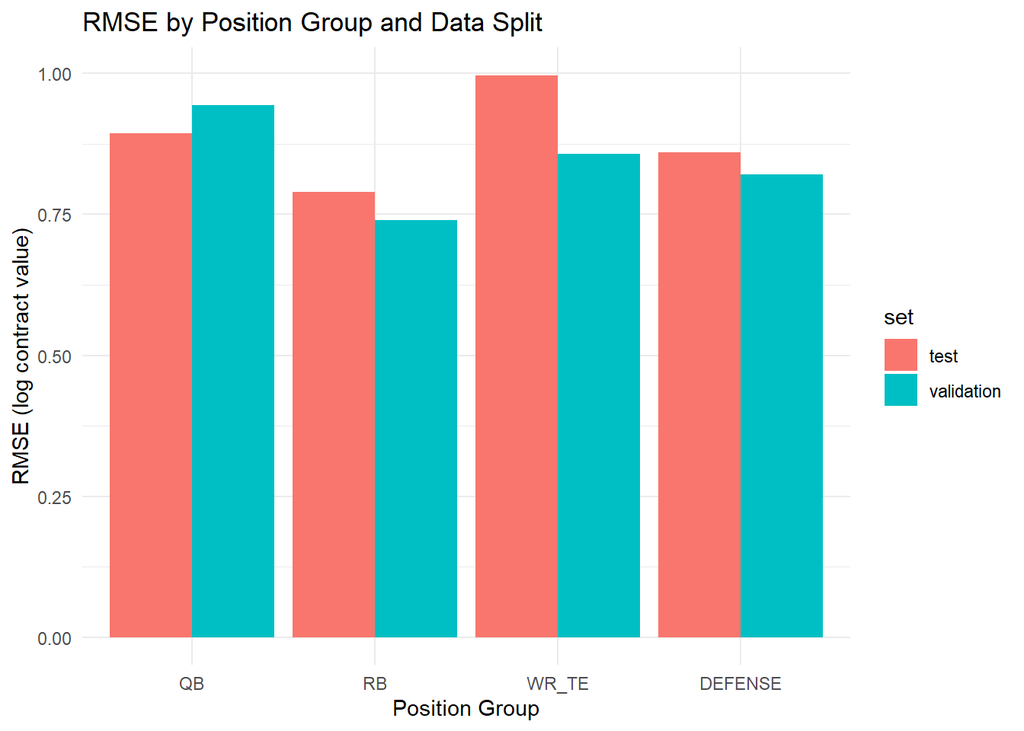

```r
ggplot(all_metrics, aes(x = pos_group, y = RMSE, fill = set)) +
  geom_col(position = "dodge") +
  labs(
    title = "RMSE by Position Group and Data Split",
    x = "Position Group",
    y = "RMSE (log contract value)"
  ) +
  theme_minimal()
```

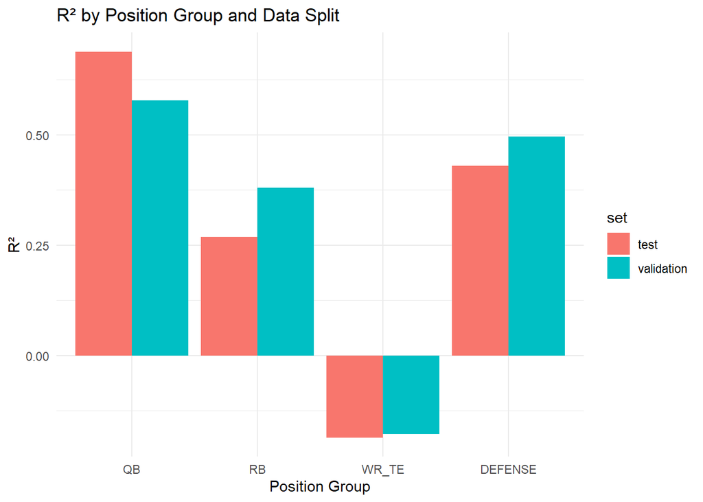

```r
ggplot(all_metrics, aes(x = pos_group, y = R2, fill = set)) +
  geom_col(position = "dodge") +
  labs(
    title = "R² by Position Group and Data Split",
    x = "Position Group",
    y = "R²"
  ) +
  theme_minimal()
```

### How to Read These Plots

- If **QB** has the highest R² and relatively low RMSE, that supports the idea that quarterback salaries track recent performance pretty closely.
- If **RB** shows moderate R² with somewhat higher RMSE, it suggests teams consider rushing and receiving production but also weigh other factors like age, workload, and injury risk.
- If **WR/TE** has low or even negative R², that indicates our simple box‑score stats are not very predictive of contract size for pass‑catchers — an interesting finding you can discuss as a limitation and an avenue for future work.
- Defensive results summarize how much basic counting stats for defenders explain variation in defensive contract values.

# 7. Coefficient Tables and Visualizations

## 7.1 Offensive Coefficients

```r
get_coef_df <- function(res_obj, label) {
  if (is.null(res_obj)) return(NULL)
  broom::tidy(res_obj$fit) %>%
    filter(term != "(Intercept)") %>%
    mutate(pos_group = label)
}

off_coefs <- bind_rows(
  get_coef_df(off_results$QB, "QB"),
  get_coef_df(off_results$RB, "RB"),
  get_coef_df(off_results$WR_TE, "WR_TE")
)

kable(
  off_coefs %>%
    select(pos_group, term, estimate, std.error, statistic, p.value) %>%
    arrange(pos_group, desc(abs(estimate))),
  digits = 3,
  caption = "Offensive Regression Coefficients (Standardized Predictors)"
)
```

Offensive Regression Coefficients (Standardized Predictors)

| pos_group | term | estimate | std.error | statistic | p.value |
| --- | --- | --- | --- | --- | --- |
| QB | pass_tds_z | 1.458 | 0.410 | 3.558 | 0.001 |
| QB | age_z | -1.326 | 0.341 | -3.890 | 0.000 |
| QB | exp_z | 1.311 | 0.347 | 3.775 | 0.000 |
| QB | pass_yards_z | -0.422 | 1.564 | -0.270 | 0.788 |
| QB | ints_z | -0.299 | 0.255 | -1.174 | 0.243 |
| QB | pass_att_z | 0.185 | 1.403 | 0.132 | 0.896 |
| RB | rush_att_z | -0.834 | 0.541 | -1.542 | 0.125 |
| RB | rush_yards_z | 0.675 | 0.583 | 1.158 | 0.248 |
| RB | exp_z | 0.298 | 0.141 | 2.109 | 0.036 |
| RB | rush_tds_z | 0.281 | 0.181 | 1.551 | 0.122 |
| RB | recs_z | 0.200 | 0.235 | 0.852 | 0.395 |
| RB | age_z | -0.095 | 0.132 | -0.723 | 0.470 |
| RB | rec_yards_z | -0.027 | 0.213 | -0.125 | 0.901 |
| WR_TE | exp_z | 0.413 | 0.159 | 2.604 | 0.011 |
| WR_TE | rec_tds_z | 0.336 | 0.103 | 3.244 | 0.002 |
| WR_TE | recs_z | 0.275 | 0.148 | 1.866 | 0.065 |
| WR_TE | age_z | -0.151 | 0.166 | -0.911 | 0.365 |
| WR_TE | rec_yards_z | 0.000 | 0.168 | -0.002 | 0.998 |

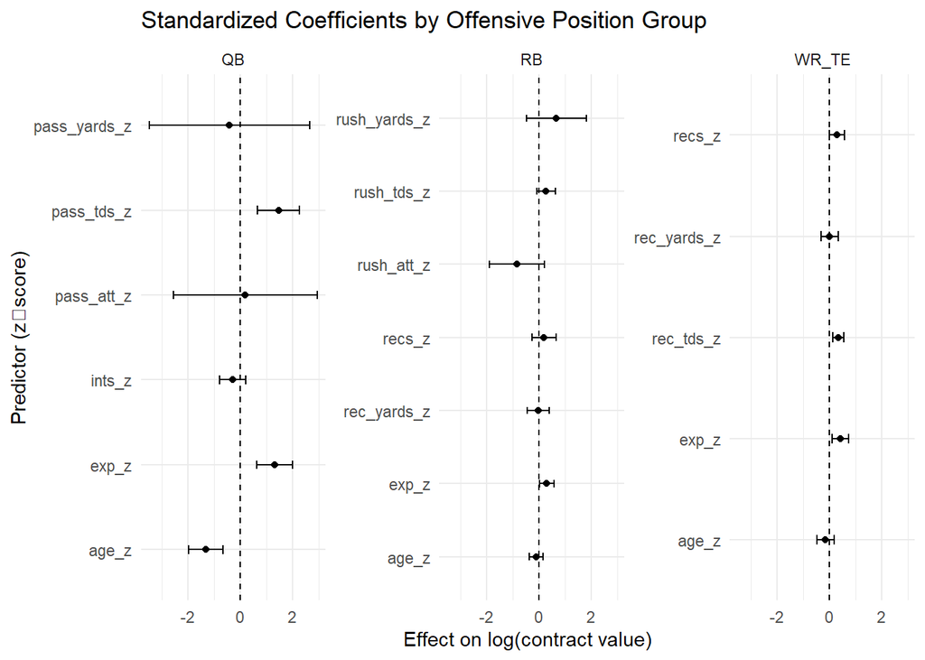

```r
ggplot(off_coefs, aes(x = term, y = estimate)) +
  geom_hline(yintercept = 0, linetype = "dashed") +
  geom_point() +
  geom_errorbar(
    aes(ymin = estimate - 1.96 * std.error,
        ymax = estimate + 1.96 * std.error),
    width = 0.1
  ) +
  coord_flip() +
  facet_wrap(~ pos_group, scales = "free_y") +
  labs(
    title = "Standardized Coefficients by Offensive Position Group",
    x = "Predictor (z‑score)",
    y = "Effect on log(contract value)"
  ) +
  theme_minimal()
```

## 7.2 Defensive Coefficients

```r
def_coefs <- broom::tidy(def_fit) %>%
  filter(term != "(Intercept)") %>%
  mutate(pos_group = "DEFENSE")

kable(
  def_coefs %>%
    select(term, estimate, std.error, statistic, p.value),
  digits = 3,
  caption = "Defensive Regression Coefficients (Standardized Predictors)"
)
```

Defensive Regression Coefficients (Standardized Predictors)

| term | estimate | std.error | statistic | p.value |
| --- | --- | --- | --- | --- |
| age_z | -0.174 | 0.039 | -4.459 | 0.000 |
| exp_z | 0.237 | 0.041 | 5.812 | 0.000 |
| tackles_z | 0.186 | 0.032 | 5.763 | 0.000 |
| sacks_z | -0.397 | 0.205 | -1.943 | 0.052 |
| qb_hits_z | 0.880 | 0.205 | 4.288 | 0.000 |
| ints_z | 0.294 | 0.035 | 8.271 | 0.000 |

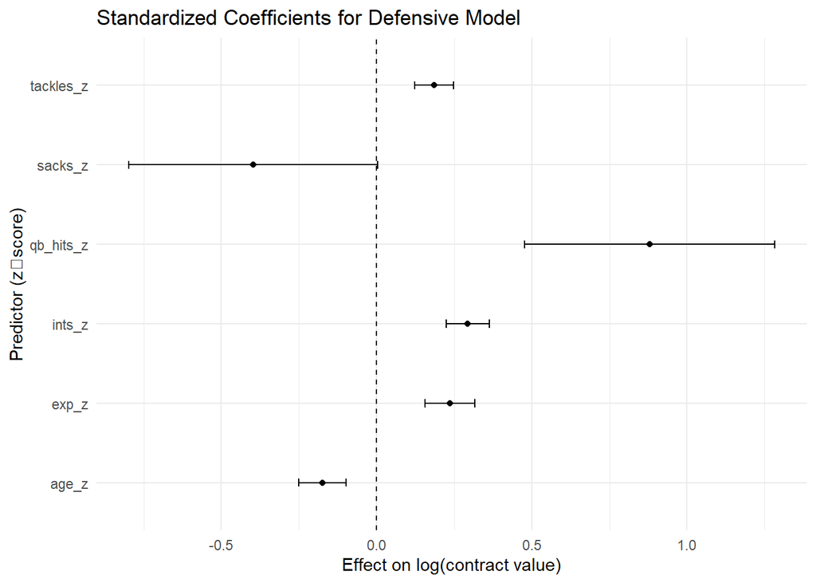

```r
ggplot(def_coefs, aes(x = term, y = estimate)) +
  geom_hline(yintercept = 0, linetype = "dashed") +
  geom_point() +
  geom_errorbar(
    aes(ymin = estimate - 1.96 * std.error,
        ymax = estimate + 1.96 * std.error),
    width = 0.1
  ) +
  coord_flip() +
  labs(
    title = "Standardized Coefficients for Defensive Model",
    x = "Predictor (z‑score)",
    y = "Effect on log(contract value)"
  ) +
  theme_minimal()
```